# TDI Project Proposal / Exploration

```r
setwd("~")
library(lubridate)
uberdat = read.csv("Transportation_Network_Providers_-_Trips.csv", header = FALSE)
```

Rather large amount of data. Lets see if we can remove any Trip ID is redundant. Centroids can be generated from lat/long

```r
names(uberdat) <- as.matrix(uberdat[1, ])
uberdat = uberdat[-1, ]
uberdat[] = lapply(uberdat, function(x) type.convert(as.character(x)))

uberdat$`Trip ID` = NULL
uberdat$`Dropoff Centroid Location` = NULL
uberdat$`Pickup Centroid Location` = NULL
```

Note census tract 17031980100 = Midway airport Census tract 17031770602, 17031980000 = Ohare Community area 76 = ohare Community area 56/64 contain midway

```r
uberdat$airportpickup = (uberdat$`Pickup Community Area`==76) | (uberdat$`Pickup Census Tract` == 17031980100)

uberdat$airportdropoff = (uberdat$`Dropoff Community Area`==76) | (uberdat$`Dropoff Census Tract` == 17031980100)

uberdat$airport = uberdat$airportpickup | uberdat$airportdropoff

sum(uberdat$airport, na.rm = TRUE)
```

```
[1] 1525351
```

```r
sum(uberdat$airportpickup,na.rm = TRUE)
```

```
[1] 681130
```

```r
sum(uberdat$airportdropoff,na.rm = TRUE)
```

```
[1] 860631
```

Slightly more dropoffs than pickups, but pretty similar. Compare airport cost/time to std

```r
mean(uberdat$'Trip Total', na.rm = TRUE)
```

```
[1] 14.29206
```

```r
mean(uberdat$'Trip Total'[uberdat$airport == TRUE], na.rm = TRUE)
```

```
[1] 36.46442
```

```r
mean(uberdat$'Trip Total'[uberdat$airportpickup == TRUE], na.rm = TRUE)
```

```
[1] 36.31532
```

```r
mean(uberdat$'Trip Total'[uberdat$airportdropoff == TRUE], na.rm = TRUE)
```

```
[1] 36.31119
```

```r
mean(uberdat$'Additional Charges', na.rm = TRUE)
```

```
[1] 2.78256
```

```r
mean(uberdat$'Additional Charges'[uberdat$airport == TRUE], na.rm = TRUE)
```

```
[1] 7.554322
```

```r
mean(uberdat$'Additional Charges'[uberdat$airportpickup == TRUE], na.rm = TRUE)
```

```
[1] 7.567391
```

```r
mean(uberdat$'Additional Charges'[uberdat$airportdropoff == TRUE], na.rm = TRUE)
```

```
[1] 7.526816
```

```r
mean(uberdat$'Trip Seconds', na.rm = TRUE)
```

```
[1] 1070.864
```

```r
mean(uberdat$'Trip Seconds'[uberdat$airport == TRUE], na.rm = TRUE)
```

```
[1] 2095.57
```

```r
mean(uberdat$'Trip Seconds'[uberdat$airportpickup == TRUE], na.rm = TRUE)
```

```
[1] 2063.366
```

```r
mean(uberdat$'Trip Seconds'[uberdat$airportdropoff == TRUE], na.rm = TRUE)
```

```
[1] 2101.342
```

Tip vs total, time

```r
lm(uberdat$'Tip' ~ uberdat$'Trip Seconds')
```

```
Call:
lm(formula = uberdat$Tip ~ uberdat$"Trip Seconds")

Coefficients:
           (Intercept)  uberdat$"Trip Seconds"
             0.0822582               0.0004246
```

```r
lm(uberdat$'Tip' ~ uberdat$'Trip Total')
```

```
Call:
lm(formula = uberdat$Tip ~ uberdat$"Trip Total")

Coefficients:
         (Intercept)  uberdat$"Trip Total"
            -0.37318               0.06368
```

Fix dates using lubridate

```r
uberdat[,1]= mdy_hms(uberdat[,1])
uberdat[,2]= mdy_hms(uberdat[,2])
```

Ideas - Tip vs Pickup / Dropoff. Use Community Areas over Census tracts here imo In order to be meaninful, want to compare vs average trip length

```r
pickup_tip = aggregate(list(tip = uberdat$Tip, time = uberdat$'Trip Seconds'), by=list(CommunityPickup=uberdat$`Pickup Community Area`), FUN=function(x) mean(x, na.rm=TRUE))
dropoff_tip = aggregate(list(tip = uberdat$Tip, time = uberdat$'Trip Seconds'), by=list(CommunityDropoff=uberdat$`Dropoff Community Area`), FUN=function(x) mean(x, na.rm=TRUE))
pickup_tip$tiprate = pickup_tip$tip/pickup_tip$time
dropoff_tip$tiprate = dropoff_tip$tip/dropoff_tip$time

pickup_tip
```

| CommunityPickup | tip | time | tiprate |
| --- | --- | --- | --- |
| 1 | 0.4956512 | 1119.4730 | 4.427540e-04 |
| 2 | 0.3264083 | 1093.1511 | 2.985939e-04 |
| 3 | 0.5089891 | 1002.9412 | 5.074964e-04 |
| 4 | 0.6211424 | 1038.0742 | 5.983603e-04 |
| 5 | 0.5715309 | 1030.2029 | 5.547751e-04 |
| 6 | 0.4354639 | 960.5245 | 4.533606e-04 |
| 7 | 0.4011411 | 901.0316 | 4.452020e-04 |
| 8 | 0.5187462 | 910.6389 | 5.696508e-04 |
| 9 | 0.6981215 | 987.2140 | 7.071632e-04 |
| 10 | 0.6092624 | 973.6515 | 6.257500e-04 |

[output cut: 67 more lines]

```r
dropoff_tip
```

| CommunityDropoff | tip | time | tiprate |
| --- | --- | --- | --- |
| 1 | 0.5089515 | 1064.3075 | 0.0004781997 |
| 2 | 0.3443139 | 1038.2138 | 0.0003316407 |
| 3 | 0.4864950 | 968.5692 | 0.0005022821 |
| 4 | 0.5813841 | 1005.6141 | 0.0005781384 |
| 5 | 0.5028989 | 949.2510 | 0.0005297850 |
| 6 | 0.4007547 | 917.2142 | 0.0004369260 |
| 7 | 0.3660341 | 869.9987 | 0.0004207294 |
| 8 | 0.5046828 | 924.4411 | 0.0005459329 |
| 9 | 0.7101408 | 998.0674 | 0.0007115159 |
| 10 | 0.5960533 | 974.3811 | 0.0006117250 |

[output cut: 67 more lines]

About an order of magnitude difference - if you care about tips, it might make sense to pickup in certain areas! Could repeat with fare per time - would expect it to be more uniform, but might still be better in some areas Use trip cost, not total (e.g. ignore tip, fees)

```r
pickup_fare = aggregate(list(fare = uberdat$Fare, time = uberdat$'Trip Seconds'), by=list(CommunityPickup=uberdat$`Pickup Community Area`), FUN=function(x) mean(x, na.rm=TRUE))
dropoff_fare = aggregate(list(fare = uberdat$Fare, time = uberdat$'Trip Seconds'), by=list(CommunityDropoff=uberdat$`Dropoff Community Area`), FUN=function(x) mean(x, na.rm=TRUE))
pickup_fare$farerate = pickup_fare$fare/pickup_fare$time
dropoff_fare$farerate = dropoff_fare$fare/dropoff_fare$time
pickup_fare
```

| CommunityPickup | fare | time | farerate |
| --- | --- | --- | --- |
| 1 | 10.464366 | 1119.4730 | 0.009347582 |
| 2 | 9.697030 | 1093.1511 | 0.008870713 |
| 3 | 9.771076 | 1002.9412 | 0.009742421 |
| 4 | 9.962137 | 1038.0742 | 0.009596748 |
| 5 | 9.914208 | 1030.2029 | 0.009623549 |
| 6 | 9.481946 | 960.5245 | 0.009871634 |
| 7 | 8.959442 | 901.0316 | 0.009943538 |
| 8 | 9.514019 | 910.6389 | 0.010447631 |
| 9 | 11.423111 | 987.2140 | 0.011571058 |
| 10 | 10.673230 | 973.6515 | 0.010962063 |

[output cut: 67 more lines]

```r
dropoff_fare
```

| CommunityDropoff | fare | time | farerate |
| --- | --- | --- | --- |
| 1 | 10.250160 | 1064.3075 | 0.009630826 |
| 2 | 9.472448 | 1038.2138 | 0.009123794 |
| 3 | 9.448450 | 968.5692 | 0.009755059 |
| 4 | 9.681255 | 1005.6141 | 0.009627206 |
| 5 | 9.225785 | 949.2510 | 0.009719015 |
| 6 | 8.969479 | 917.2142 | 0.009779046 |
| 7 | 8.458386 | 869.9987 | 0.009722297 |
| 8 | 9.141802 | 924.4411 | 0.009889004 |
| 9 | 11.756761 | 998.0674 | 0.011779526 |
| 10 | 10.927052 | 974.3811 | 0.011214352 |

[output cut: 67 more lines]

As expected, less variable. Still some variation, up to ~50% though For a more thorough version, compute rates per entry, then aggregate into pickup/dropoff, rather than this way Might be worth for tip data, not for less interesting fare Get Inf from division by 0. Weight by trip time, set min trip time to 1?

```r
uberdat$tiprate = uberdat$Tip/pmax(uberdat$'Trip Seconds',1, na.rm = TRUE)
uberdat$'triptime' = pmax(uberdat$'Trip Seconds',1,na.rm = TRUE)
library(plyr)
ddply(uberdat, .(`Pickup Community Area`), summarize, mean = mean(tiprate, na.rm = TRUE), wmean = weighted.mean(tiprate, w=triptime, na.rm = TRUE))
```

| Pickup Community Area | mean | wmean |
| --- | --- | --- |
| 1 | 0.0006825479 | 4.428106e-04 |
| 2 | 0.0004179212 | 2.986126e-04 |
| 3 | 0.0008243032 | 5.076779e-04 |
| 4 | 0.0008522451 | 5.984253e-04 |
| 5 | 0.0008213196 | 5.548602e-04 |
| 6 | 0.0006542343 | 4.534600e-04 |
| 7 | 0.0005807861 | 4.452817e-04 |
| 8 | 0.0007840726 | 5.697588e-04 |
| 9 | 0.0011983786 | 7.074334e-04 |
| 10 | 0.0010146672 | 6.258832e-04 |

[output cut: 68 more lines]

Ideas - Cost / Time, measured by region and or time of day (surge) First need to get time of day, either categories or continuous Lets try categories Rush hour - 6-8 AM, 4-6 PM Early - 8-12, afternoon 12-4, evening 6-10, night 10-6 How to decide when a trip occurs? Use centerpoint? Works for all but longest trips Or, the goal is to generate a nice plot. Probably works better if we do a continuous plot. Start of trip vs cost rate. Other factors - Day of week, time of year(mont?), location of dropoff / pickup

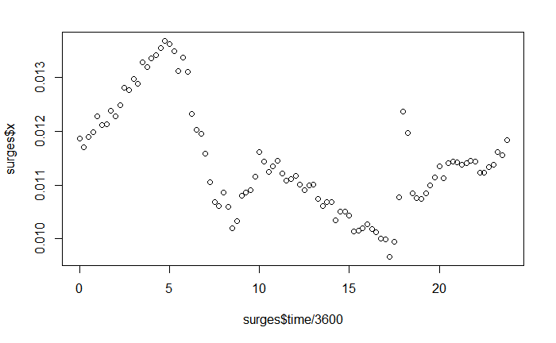

```r
uberdat$midpoint = uberdat$'Trip Start Timestamp' + as.duration(.5*as.interval(uberdat$'Trip Start Timestamp', uberdat$'Trip End Timestamp'))
uberdat$midtime = hour(uberdat$midpoint)*3600 + minute(uberdat$midpoint)*60 + second(uberdat$midpoint)
uberdat$starttime = hour(uberdat$'Trip Start Timestamp')*3600 + minute(uberdat$'Trip Start Timestamp')*60
uberdat$day = wday(uberdat$midpoint)
uberdat$month = month(uberdat$midpoint)
uberdat$eff = uberdat$Fare/pmax(uberdat$'Trip Seconds',1, na.RM = TRUE)
uberdat$starttime = hour(uberdat$'Trip Start Timestamp')*3600 + minute(uberdat$'Trip Start Timestamp')*60

surges = aggregate(uberdat$eff, by = list(time = uberdat$starttime), FUN = function(x) mean(x, na.rm = TRUE))
plot(surges$time/3600, surges$x)
```

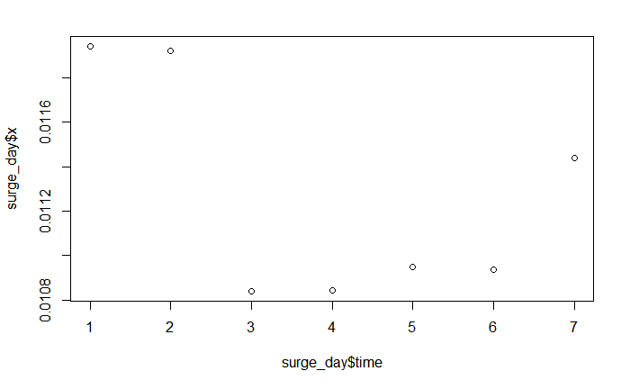

```r
surge_day = aggregate(uberdat$eff, by = list(time = uberdat$day), FUN = function(x) mean(x, na.rm = TRUE))
plot(surge_day$time, surge_day$x)
```

Compare surge pricing based on pickup/dropoff

```r
pickup_surge = aggregate(list(eff = uberdat$eff), by=list(CommunityPickup=uberdat$`Pickup Community Area`), FUN=function(x) mean(x, na.rm=TRUE))
dropoff_surge = aggregate(list(eff = uberdat$eff), by=list(CommunityDropoff=uberdat$`Dropoff Community Area`), FUN=function(x) mean(x, na.rm=TRUE))
```

Tip rate vs surge pricing

```r
lm(uberdat$tiprate ~ uberdat$eff)
```

```
Call:
lm(formula = uberdat$tiprate ~ uberdat$eff)

Coefficients:
(Intercept)  uberdat$eff
  0.0002913    0.0275032
```

Tip rate scales with cost rate - so tip is based on total cost, not time

Tip rate vs time

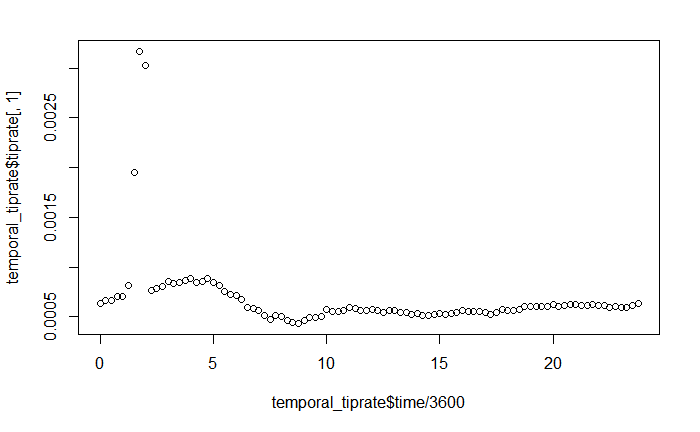

```r
temporal_tiprate = aggregate(list(tiprate = uberdat$tiprate), by=list(time = uberdat$starttime), FUN=function(x) c(mean(x, na.rm=TRUE), N = length(x)))
plot(temporal_tiprate$time/3600, temporal_tiprate$tiprate[,1]) # massive spike for certain late night runs.
```

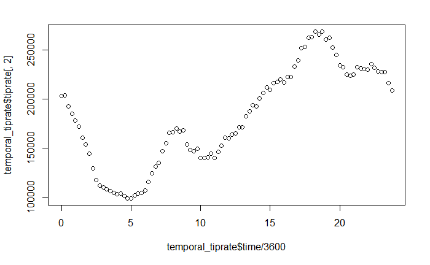

```r
plot(temporal_tiprate$time/3600, temporal_tiprate$tiprate[,2]) # fair amount of data - seems to be a real effect
```

Trip length vs time

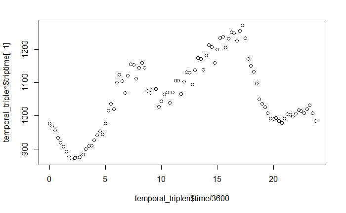

```r
temporal_triplen = aggregate(list(triptime = uberdat$`Trip Seconds`), by=list(time = uberdat$starttime), FUN=function(x) c(mean(x, na.rm=TRUE), N = length(x)))
plot(temporal_triplen$time/3600, temporal_triplen$triptime[,1])
```

Rush hour trips are longest

Area vs time

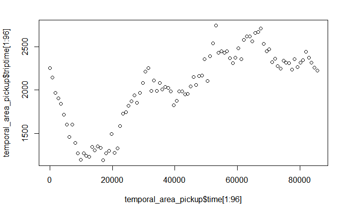

```r
temporal_area_pickup = aggregate(list(triptime = uberdat$`Trip Seconds`), by=list(time = uberdat$starttime, CommunityPickup=uberdat$`Pickup Community Area`), FUN=function(x) length(x))
temporal_area_dropoff = aggregate(list(triptime = uberdat$`Trip Seconds`), by=list(time = uberdat$starttime, CommunityDropoff=uberdat$`Dropoff Community Area`), FUN=function(x) length(x))
plot(temporal_area_pickup$time[1:96], temporal_area_pickup$triptime[1:96])
```

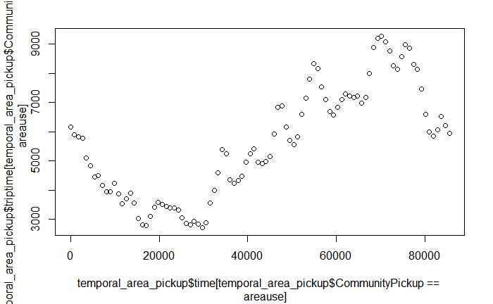

```r
areause = 76 # ohare
plot(temporal_area_pickup$time[temporal_area_pickup$CommunityPickup==areause],temporal_area_pickup$triptime[temporal_area_pickup$CommunityPickup==areause])
```

Assuming total driver compensation is tipping + fare (but not fee) Overall compensation vs time

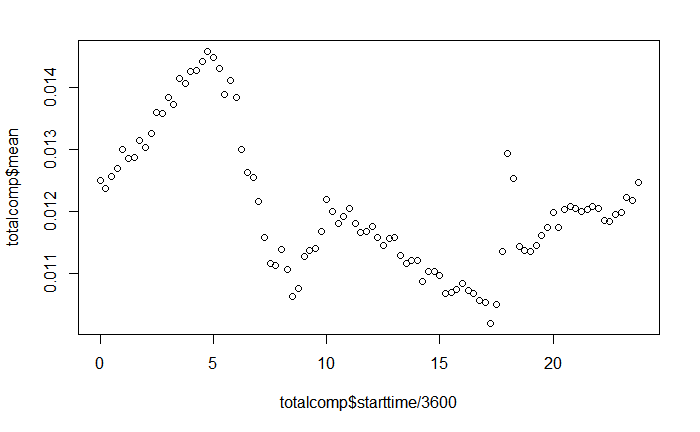

```r
uberdat$overallrate = uberdat$eff + uberdat$tiprate
library(plyr)
totalcomp = ddply(uberdat, .(`starttime`), summarize, mean = mean(overallrate, na.rm = TRUE), wmean = weighted.mean(overallrate, w=triptime, na.rm = TRUE), trips = length(overallrate))
plot(totalcomp$starttime/3600, totalcomp$mean)
```

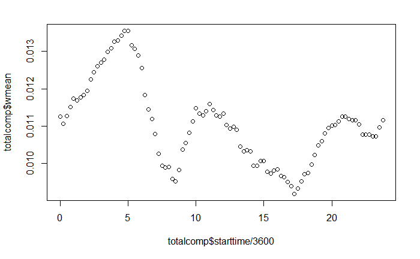

```r
plot(totalcomp$starttime/3600, totalcomp$wmean)
```

```r
totalcompairport = ddply(uberdat[uberdat$airport==TRUE,], .(`starttime`), summarize, airmean = mean(overallrate, na.rm = TRUE), airwmean = weighted.mean(overallrate, w=triptime, na.rm = TRUE), airtrips = length(overallrate))
```

Tips don’t seem to make a huge difference. Overall, as a passenger cheapest time to ride is during rush hour. As a driver, best time to drive is early in the morning, lunch time, or evening.

What about runs involving airports? And total runs? Put it all together

Final Plots of most interesting findings:

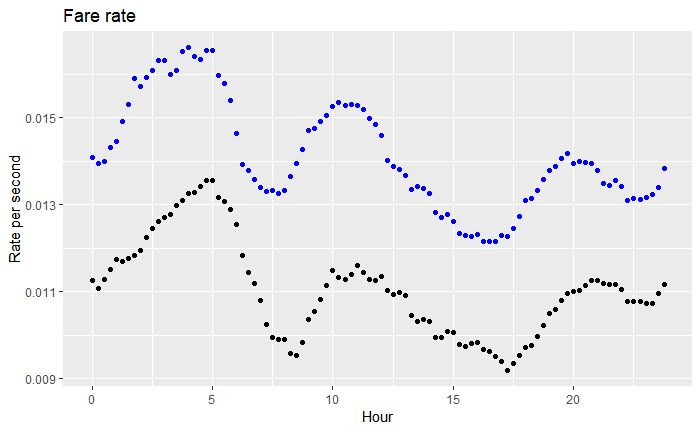

```r
library(ggplot2)

totalcomp2 = merge(totalcomp,totalcompairport)
ggplot(data = totalcomp2) +
  geom_point(
    mapping = aes(x = starttime/3600, y = wmean),
    show.legend = FALSE
  ) +
  geom_point(mapping = aes(x = starttime/3600, y = airwmean), color = "blue", show.legend = FALSE
  ) + ggtitle("Fare rate") +
  xlab("Hour") + ylab("Rate per second")
```

Ideas - Comparison vs Taxi Data Taxi Data too large for R - will have to be done via API or online

Online API exists to get reduced subsets of data

Call 2014 data the peak, 2016 data the declined version, as seen via online visualization Use data from same 2 months as in the uberdat set, e.g. 11/12 from year 2014, 2016 while uber dat is 11/12 from 2018

Goals - 2014(11/12) compared to 2016(11/12) Check summary statistics (trip length, cost)

https://data.cityofchicago.org/resource/wrvz-psew.json?$query=SELECT avg(trip_seconds) WHERE(date_extract_m(trip_start_timestamp)=11%20OR%20date_extract_m(trip_start_timestamp)=12)%20AND%20date_extract_y(trip_start_timestamp)%20=%202014

[{“avg_trip_seconds”:“710.4160505317120059”}]

https://data.cityofchicago.org/resource/wrvz-psew.json?$query=SELECT avg(trip_seconds) WHERE(date_extract_m(trip_start_timestamp)=11%20OR%20date_extract_m(trip_start_timestamp)=12)%20AND%20date_extract_y(trip_start_timestamp)%20=%202016

[{“avg_trip_seconds”:“800.9971126453857209”}]

Minor increase in trip length.

Fare or trip total? Lets go by trip_total

https://data.cityofchicago.org/resource/wrvz-psew.json?$query=SELECT avg(trip_total) WHERE(date_extract_m(trip_start_timestamp)=11%20OR%20date_extract_m(trip_start_timestamp)=12)%20AND%20date_extract_y(trip_start_timestamp)%20=%202014

[{“avg_trip_total”:“13.9482352993811475”}]

https://data.cityofchicago.org/resource/wrvz-psew.json?$query=SELECT avg(trip_total) WHERE(date_extract_m(trip_start_timestamp)=11%20OR%20date_extract_m(trip_start_timestamp)=12)%20AND%20date_extract_y(trip_start_timestamp)%20=%202016

[{“avg_trip_total”:“15.9135056361069580”}]

```r
mean(uberdat$'Trip Total', na.rm = TRUE) # 14.3
```

```
[1] 14.29206
```

Minor increase, but no real difference when compared with ride share data

Check Trip total by monthly

https://data.cityofchicago.org/resource/wrvz-psew.csv?$query=SELECT avg(trip_total) GROUP BY date_trunc_ym(trip_start_timestamp)

[{“avg_trip_total”:“16.9698289385950832”} ,{“avg_trip_total”:“14.8153904805303267”} ,{“avg_trip_total”:“14.2885991998022783”} ,{“avg_trip_total”:“13.1723788371973061”} ,{“avg_trip_total”:“13.7998990057807667”} ,{“avg_trip_total”:“17.3639463529291162”} ,{“avg_trip_total”:“14.2253599325717884”} ,{“avg_trip_total”:“15.9327578626464004”} ,{“avg_trip_total”:“15.0952281877060484”} ,{“avg_trip_total”:“15.4901513173493049”} ,{“avg_trip_total”:“15.6752902212465685”} ,{“avg_trip_total”:“15.0704149509371371”} ,{“avg_trip_total”:“14.8400833967800186”} ,{“avg_trip_total”:“15.6215529457945677”} ,{“avg_trip_total”:“14.9142888103184579”} ,{“avg_trip_total”:“17.5001247487279473”} ,{“avg_trip_total”:“15.6431927180309933”} ,{“avg_trip_total”:“16.3096386868719068”} ,{“avg_trip_total”:“16.2869691489855862”} ,{“avg_trip_total”:“16.7599258017663613”} ,{“avg_trip_total”:“14.4445111055420649”} ,{“avg_trip_total”:“16.3107042253521127”} ,{“avg_trip_total”:“17.1340970107467920”} ,{“avg_trip_total”:“13.3467635799433326”} ,{“avg_trip_total”:“15.2632445583614845”} ,{“avg_trip_total”:“13.5312415211228743”} ,{“avg_trip_total”:“14.7263871199755028”} ,{“avg_trip_total”:“17.0955145413178960”} ,{“avg_trip_total”:“15.5751539574431269”} ,{“avg_trip_total”:“15.7506073376117520”} ,{“avg_trip_total”:“15.2077081077005721”} ,{“avg_trip_total”:“13.4123675647459844”} ,{“avg_trip_total”:“14.3574332829813733”} ,{“avg_trip_total”:“14.3526274839577727”} ,{“avg_trip_total”:“15.2401978368530714”} ,{“avg_trip_total”:“16.9037314931034325”} ,{“avg_trip_total”:“16.6905866105030556”} ,{“avg_trip_total”:“15.4245113017995117”} ,{“avg_trip_total”:“13.4357348197707628”} ,{“avg_trip_total”:“14.5546118087051306”} ,{“avg_trip_total”:“15.6757976276248653”} ,{“avg_trip_total”:“14.1241688075125180”} ,{“avg_trip_total”:“14.1445852610979772”} ,{“avg_trip_total”:“13.8711766247587582”} ,{“avg_trip_total”:“17.4473299803417542”} ,{“avg_trip_total”:“15.1068169307113250”} ,{“avg_trip_total”:“14.8919308468933444”} ,{“avg_trip_total”:“15.3645502916440073”} ,{“avg_trip_total”:“13.9712394775882681”} ,{“avg_trip_total”:“16.6454643986298917”} ,{“avg_trip_total”:“17.2983715444256008”} ,{“avg_trip_total”:“14.3701887785152669”} ,{“avg_trip_total”:“14.1278253117647451”} ,{“avg_trip_total”:“14.8347730682199128”} ,{“avg_trip_total”:“14.0501274566805247”} ,{“avg_trip_total”:“14.3290600659966493”}]

Preliminary - looks like (overall) shorter trips are being reduced. New idea - check (by month, over full dataset) the proportion of trips under <10$

```r
mean(uberdat$'Trip Total' < 10, na.rm = TRUE)
```

```
[1] 0.3590105
```

https://data.cityofchicago.org/resource/wrvz-psew.csv?$query=SELECT count(trip_total) WHERE trip_total<10 GROUP BY date_trunc_ym(trip_start_timestamp)

```r
taxi_sub10 = read.csv("wrvz-psew(sub10).csv", header = TRUE)
```

https://data.cityofchicago.org/resource/wrvz-psew.csv?$query=SELECT count(trip_total) GROUP BY date_trunc_ym(trip_start_timestamp)

```r
taxi_all = read.csv("wrvz-psew(all).csv", header = TRUE)
```

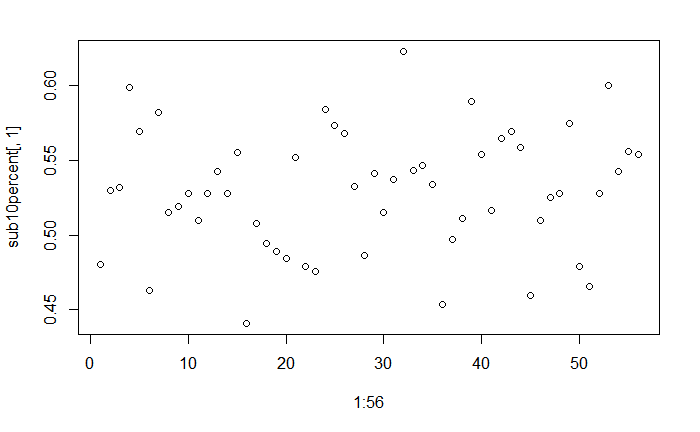

```r
sub10percent = taxi_sub10/taxi_all
plot(1:56,sub10percent[,1])
```

no real trend. Notably, uberdat has a lower percentage of sub 10

Could alternatively check high

```r
mean(uberdat$'Trip Total' > 50, na.rm = TRUE)
```

```
[1] 0.01581239
```

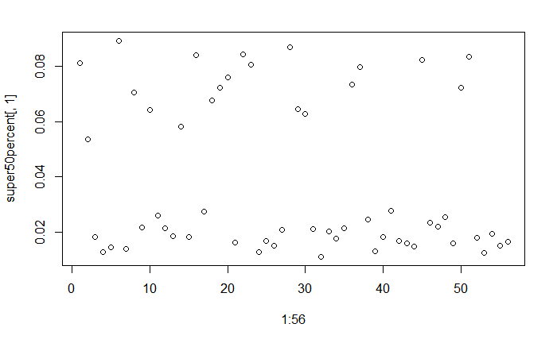

```r
taxi_super50 = read.csv("wrvz-psew(super50).csv", header = TRUE)
super50percent = taxi_super50/taxi_all
plot(1:56,super50percent[,1])
```

```r
lm(super50percent[,1] ~ c(1:56))
```

```
Call:
lm(formula = super50percent[, 1] ~ c(1:56))

Coefficients:
(Intercept)      c(1:56)
  0.0485689   -0.0003562
```

not much of a change

Does competition from uber change pricing? Check price efficiency (rate per trip length) over monthly

https://data.cityofchicago.org/resource/wrvz-psew.csv?$query=SELECT avg(fare), avg(trip_seconds) GROUP BY date_trunc_ym(trip_start_timestamp)

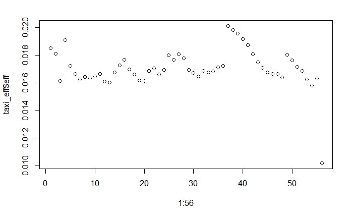

```r
taxi_eff = read.csv("wrvz-psew(montlyeff).csv", header = TRUE)
taxi_eff$eff = taxi_eff$avg_fare/taxi_eff$avg_trip_seconds
plot(1:56,taxi_eff$eff)
```

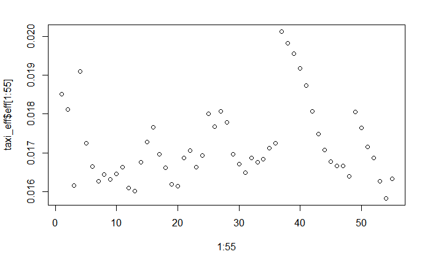

```r
# assuming the last is an outlier
plot(1:55,taxi_eff$eff[1:55])
```

```r
lm(taxi_eff$eff[1:55] ~ c(1:55))
```

```
Call:
lm(formula = taxi_eff$eff[1:55] ~ c(1:55))

Coefficients:
(Intercept)      c(1:55)
  1.702e-02    6.612e-06
```

no real temporal change

Does tipping behavior change over time?

https://data.cityofchicago.org/resource/wrvz-psew.csv?$query=SELECT avg(fare), avg(trip_seconds), avg(tips), date_trunc_ym(trip_start_timestamp) GROUP BY date_trunc_ym(trip_start_timestamp)

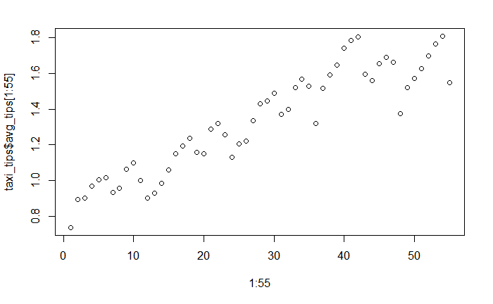

```r
taxi_tips = read.csv("wrvz-psew(tips).csv", header = TRUE)
# tips
plot(1:55,taxi_tips$avg_tips[1:55])
```

```r
lm(taxi_tips$avg_tips[1:55]~c(1:55))
```

```
Call:
lm(formula = taxi_tips$avg_tips[1:55] ~ c(1:55))

Coefficients:
(Intercept)      c(1:55)
     0.8631       0.0168
```

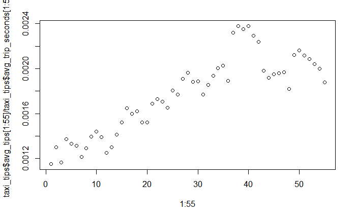

```r
# tips per time
plot(1:55,taxi_tips$avg_tips[1:55]/taxi_tips$avg_trip_seconds[1:55])
```

```r
lm(taxi_tips$avg_tips[1:55]/taxi_tips$avg_trip_seconds[1:55]~c(1:55))
```

```
Call:
lm(formula = taxi_tips$avg_tips[1:55]/taxi_tips$avg_trip_seconds[1:55] ~
    c(1:55))

Coefficients:
(Intercept)      c(1:55)
  1.251e-03    1.845e-05
```

Tips increase over time, and are more generous than riseshare tips. Ongoing debate over uber/compensation may have raised awareness.

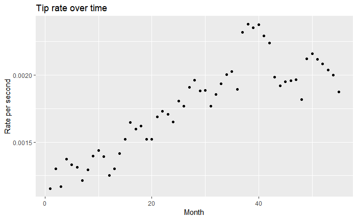

```r
taxi_tips$tiprate = taxi_tips$avg_tips/taxi_tips$avg_trip_seconds
taxi_tips$index = c(1:56)
ggplot(data = taxi_tips[1:55,]) +
  geom_point(
    mapping = aes(x = index, y =tiprate),
    show.legend = FALSE
  ) + ggtitle("Tip rate over time") +
  xlab("Month") + ylab("Rate per second")
```